# Churn Probability Prediction at Small Scale

Tony Yao-Jen Kuo

July 21, 2016

## Summary

|  | Decision Tree |
| --- | --- |
| Accuracy: | 0.94 |
| Precision: | 0.89 |
| Important predictors: | DAYS_LAST_WEB_VISIT |
|  | DAYS_FIRST_PURCHASE |
|  | DAYS_LAST_PURCHASE |
|  | COUPANG_CASH_USAGE |

|  | Random Forest |
| --- | --- |
| Accuracy: | 0.97 |
| Precision: | 0.97 |
| Important predictors: | DAYS_LAST_WEB_VISIT |
|  | DAYS_FIRST_PURCHASE |
|  | DAYS_LAST_PURCHASE |
|  | ACQUISITION_CHANNEL |
|  | ROCKET_CT |
|  | COUPANG_CASH_USAGE |

## Predictors

We’ve collected a total of **56** predictors from different data sources(PDA and Hive) and the main categories are:

- Purchase history by customer
- Purchase history by customer and product categories
- Engagement data by customer
- Acquisition data by customer
- Acquisition data by customer and product categories
- Demographic data by customer
- Customer service data by customer and contact types
- Product review data by customer

## Data at Small Scale

```r
str(tmp_abt_modeling)
```

```
## 'data.frame':    105000 obs. of  57 variables:
##  $ CHURN_FLAG                    : Factor w/ 2 levels "0","1": 2 2 2 2 1 2 2 2 2 2 ...
##  $ GENDER                        : Factor w/ 3 levels "F","M","N": 2 2 1 1 2 2 2 1 2 1 ...
##  $ ACQUISITION_CHANNEL           : Factor w/ 4 levels "Mobile","Mobile_WEB",..: 4 3 3 3 1 3 3 3 3 3 ...
##  $ ACQUISITION_PUBLISHER         : Factor w/ 84 levels "Adam","Adbay DA",..: 72 72 72 72 72 72 72 72 72 72 ...
##  $ COUPON_USAGE                  : num  0 0 0 0 0 0 0 0 0 0 ...
##  $ COUPANG_CASH_USAGE            : int  0 0 3000 0 0 0 0 0 0 36175 ...
##  $ ROCKET_CT                     : int  0 0 79 8 12 144 0 16 36 270 ...
##  $ NEW_WKD_ROCKET_CT             : int  0 0 17 0 8 108 0 0 0 50 ...
##  $ GLOBAL_CT                     : int  0 0 0 0 0 0 0 0 0 0 ...
##  $ MAPLE_CT                      : int  0 0 0 0 0 0 0 0 0 0 ...
##  $ ROCKETPAY_CT                  : int  0 0 0 0 0 0 0 0 0 0 ...
##  $ ACCESSORIES_FIRST_PURCHASED   : num  0 0 0 0 0 0 0 0 0 0 ...
##  $ BABY_FIRST_PURCHASED          : num  0 0 0 0 0 0 0 0 0 0 ...
##  $ BEAUTY_FIRST_PURCHASED        : num  26000 0 0 0 98000 0 0 0 0 0 ...
```

[output cut: 43 more lines]

We shuffled the data and separate them into train and test with a traditional 70/30 split. We will build our model based on train data and validate on test data. Let us take a glimpse of the dimensions of train and test, respectively:

```
## [1] 73500    57
```

```
## [1] 31500    57
```

## First Model: Decision Tree

Before jumping into **random forest**, let us quickly fit a decision tree using `rpart` package first.

```r
tree <- rpart(formula = CHURN_FLAG ~ ., data = train, method = "class")
```

And the confusion matrix is pretty nice:

```
##       Prediction
## Actual     0     1
##      0 23388   747
##      1  1077  6288
```

Besides binary predictions, we could also get the probability:

```
##                0          1
## 11517  0.9517936 0.04820642
## 103658 0.9517936 0.04820642
## 26434  0.0000000 1.00000000
## 101017 0.9517936 0.04820642
## 39657  0.9517936 0.04820642
## 3460   0.0000000 1.00000000
```

So let us calculate 2 performance metrics for the decision tree model:

```r
accuracy
```

```
## [1] 0.9420952
```

```r
precision
```

```
## [1] 0.8938166
```

It seemed that we got a pretty good model!

```r
# add k-fold cross validation here
```

Under default setting (complexity parameter sets at 0.01 and using GINI impurity to split data), the top predictors are:

- DAYS_LAST_WEB_VISIT(Engagement)
- DAYS_FIRST_PURCHASE(Acquisition)
- DAYS_LAST_PURCHASE(Purchase history)
- COUPANG_CASH_USAGE(Purchase history)

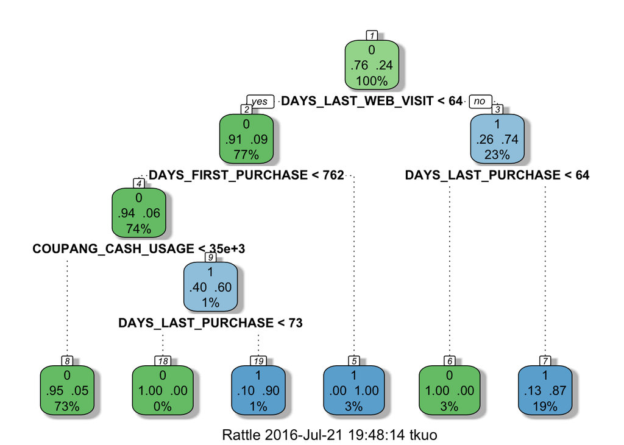

## Second Model: Random Forest

Random Forest model in R does not allow NAs.

Our review data has **a lot of**(Approximately 95%) missing value that cannot be imputed. Since the rating of product review is at a scale of 1 to 5, if we impute NAs with 0s or median, which might distort the predictors. So before modeling random forest, we will just exclude the predicotrs:

- MIN_RATING
- MAX_RATING
- AVG_RATING

And the same reason also applies to engagement data:

- DAYS_LAST_ANDROID_VISIT
- DAYS_LAST_IOS_VISIT

Random Forest model in R does not allow factors with more than 32 levels, either. So we will impute the predictor `ACQUISITION_PUBLISHER`:

```
##
##                 App Push               Daily Mail                  Daum SA
##                      678                     1209                      609
##                Google SA    Mobileweb Full Banner Mobileweb Quarter Banner
##                      115                      777                       59
##                 Naver SA                  Organic         Other Publishers
##                     3267                    55938                    10848
```

Now we can start modeling with Random Forest!

```r
# It takes too long to run the model, so I just comment it
#forest <- randomForest(CHURN_FLAG ~ ., data = train_rf, importance = TRUE, ntree = 2000)
```

At first, let us check the the confusion matrix:

```
##       Prediction
## Actual     0     1
##      0 23897   238
##      1   710  6655
```

Besides binary predictions, we could also get the probability:

```
##             0      1
## 11517  0.9260 0.0740
## 103658 1.0000 0.0000
## 26434  0.0015 0.9985
## 101017 0.9985 0.0015
## 39657  0.9940 0.0060
## 3460   0.0135 0.9865
```

It seemed that we’ve got a very good prediction model using Random Forest. Let us now calculate the 2 performance metrics:

The performance improves significantly from Decision Tree, especially for precision.

```r
accuracy
```

```
## [1] 0.9699048
```

```r
precision
```

```
## [1] 0.9654722
```

Under default setting (except number of trees sets at 2,000), the top predictors are:

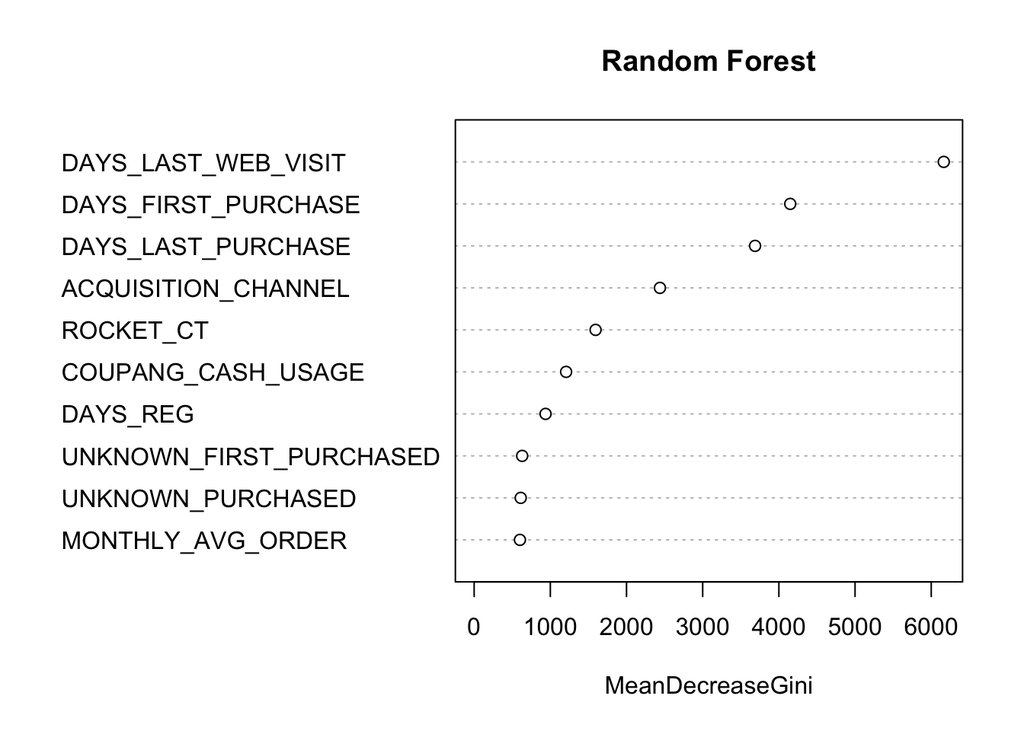

© Tony Yao-Jen Kuo